# Simulation Exercise for the Exponential Distribution

## Author: Edward Lau

### Overview: I am going to report on a simulation exercise and inferential data analysis. The first part will examine how the exponential distribution behaves under simulation. The second part will analyze the ToothGrowth data in the R dataset package.

## Part 1: Exponential distribution simulation

The following code will do 1000 simulations of random exponential distribution with lambda = 0.2

```r
sim <- 1000
means = NULL
vars = NULL
for (i in 1: sim){
        means <- c(means, mean(rexp(40,0.2)))
        vars <- c(vars, var(rexp(40,0.2)))
        }
```

The histogram of the simulation result is below:

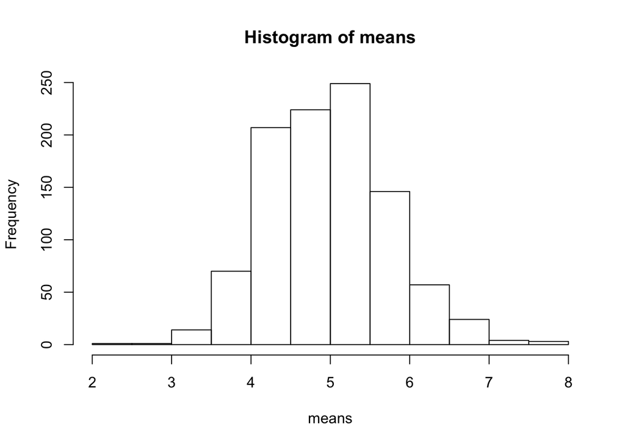

```r
hist(means)
```

### Question 1: The mean of the simulated values:

```r
mean(means)
```

```
## [1] 4.968429
```

which compares quite well to the theoretical value of 1/0.2 = 5.

### Question 2: The standard deviation of the distribution:

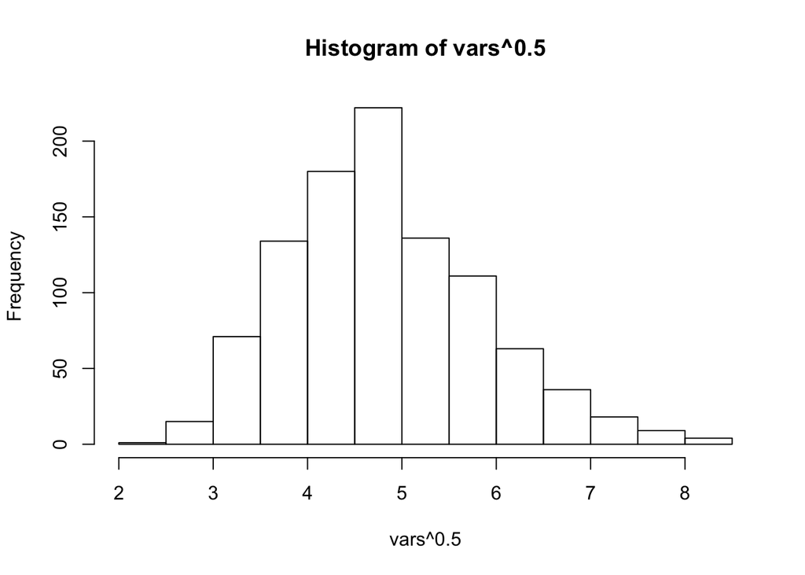

```r
hist(vars^0.5)
```

```r
mean(vars^0.5)
```

```
## [1] 4.827206
```

Hence the variance of the simulation is about (1/0.2)^2 ~ 25; and the standard deviation ~5, which compares quite well to the theoretical value of 1/0.2 = 5.

### Question 3: Normal distribution?

```r
quantile(means)
```

```
##       0%      25%      50%      75%     100%
## 2.419005 4.409663 4.958850 5.459729 7.806895
```

```r
quantile(rnorm(1000,mean=mean(means), sd=sd(means)))
```

```
##       0%      25%      50%      75%     100%
## 2.957972 4.454781 4.929363 5.443614 7.684512
```

It seems like the quantiles of the two distributions are quite comparable…

## Part 2: Inference

This will load the ToothGrowth dataset, which examines the effect of Vitamin C on tooth growth in guinea pigs. len = length of teeth for 10 guinea pigs; supp = OC or VC delivery methods (orange juice or ascorbic acid); dose = dose level

### Question 1: Load the ToothGrowth data and perform basic exploratory data analyses

```r
library(datasets)
library(dplyr)
```

```r
library(ggplot2)
glimpse(ToothGrowth)
```

```
## Observations: 60
## Variables:
## $ len  (dbl) 4.2, 11.5, 7.3, 5.8, 6.4, 10.0, 11.2, 11.2, 5.2, 7.0, 16....
## $ supp (fctr) VC, VC, VC, VC, VC, VC, VC, VC, VC, VC, VC, VC, VC, VC, ...
## $ dose (dbl) 0.5, 0.5, 0.5, 0.5, 0.5, 0.5, 0.5, 0.5, 0.5, 0.5, 1.0, 1....
```

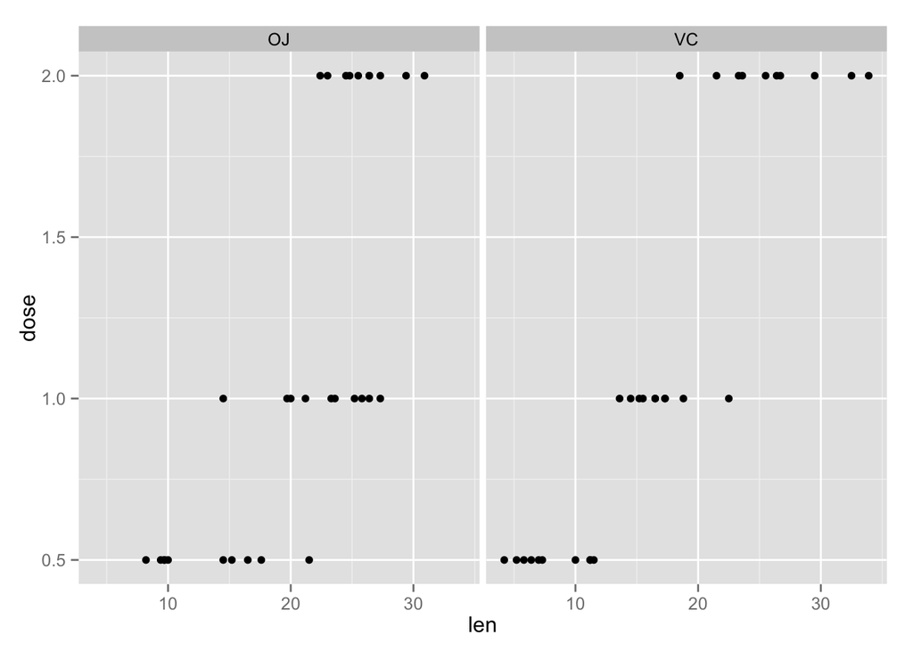

```r
qplot(len, dose, data = ToothGrowth, facets = .~supp)
```

Conclusion: it looks like there are increases in tooth length by doses of OJ and VC.

### Question 2: Summarizing the data by dose and supp.

```r
group_by(ToothGrowth, supp, dose) %>% summarize(mean = mean(len))
```

```
## Source: local data frame [6 x 3]
## Groups: supp
##
##   supp dose  mean
## 1   OJ  0.5 13.23
## 2   OJ  1.0 22.70
## 3   OJ  2.0 26.06
## 4   VC  0.5  7.98
## 5   VC  1.0 16.77
## 6   VC  2.0 26.14
```

### Question 3: Compare dose and supplement delivery method using a t test

```r
OJdata_0.5 <-filter(ToothGrowth, supp=="OJ", dose == 0.5)
VCdata_0.5 <-filter(ToothGrowth, supp=="VC", dose == 0.5)
t.test(OJdata_0.5$len,VCdata_0.5$len)
```

```
##
##  Welch Two Sample t-test
##
## data:  OJdata_0.5$len and VCdata_0.5$len
## t = 3.1697, df = 14.969, p-value = 0.006359
## alternative hypothesis: true difference in means is not equal to 0
## 95 percent confidence interval:
##  1.719057 8.780943
## sample estimates:
## mean of x mean of y
##     13.23      7.98
```

```r
OJdata_1.0 <-filter(ToothGrowth, supp=="OJ", dose == 1.0)
VCdata_1.0 <-filter(ToothGrowth, supp=="VC", dose == 1.0)
t.test(OJdata_1.0$len,VCdata_1.0$len)
```

```
##
##  Welch Two Sample t-test
##
## data:  OJdata_1.0$len and VCdata_1.0$len
## t = 4.0328, df = 15.358, p-value = 0.001038
## alternative hypothesis: true difference in means is not equal to 0
## 95 percent confidence interval:
##  2.802148 9.057852
## sample estimates:
## mean of x mean of y
##     22.70     16.77
```

```r
OJdata_2.0 <-filter(ToothGrowth, supp=="OJ", dose == 2.0)
VCdata_2.0 <-filter(ToothGrowth, supp=="VC", dose == 2.0)
t.test(OJdata_2.0$len,VCdata_2.0$len)
```

```
##
##  Welch Two Sample t-test
##
## data:  OJdata_2.0$len and VCdata_2.0$len
## t = -0.046136, df = 14.04, p-value = 0.9639
## alternative hypothesis: true difference in means is not equal to 0
## 95 percent confidence interval:
##  -3.79807  3.63807
## sample estimates:
## mean of x mean of y
##     26.06     26.14
```

Conclusion: it appears that there is a significant difference in tooth length when given low doses (0.5 and 1.0) of vitamin C through orange juice and through ascorbic acids, but this significance is no longer there at high doses (2.0)